# Somatória de Convolução

Renato Naville Watanabe

Aqui, vamos desenvolver um método para encontrar a saída $y[n]$ de um sistema discreto linear e invariante no tempo para uma entrada $x[n]$ qualquer.

[figure not shown]

Vamos considerar que conhecemos a resposta ao impulso do sistema.

[figure not shown]

Como o sistema é linear e invariante no tempo se usarmos como entrada o impulso unitário multiplicado por um valor real e atrasado de algumas unidades de tempo ($\alpha\delta[n-N]$), a saída será $\alpha h[n-N]$ (multiplicada pelo mesmo valor e atrsada do mesmo número de unidades no tempo).

[figure not shown]

Em sinais de tempo discreto, é simples escrever um sinal $x[n]$ qualquer como uma soma ponderada de impulsos atrasados.

Vamos exemplificar com um sinal $x[n]$ qualquer:

```
<StemContainer object of 3 artists>
```

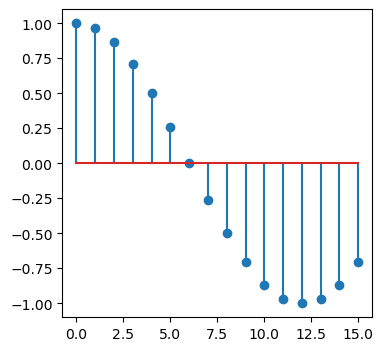

Se multiplicarmos o sinal por $\delta[0]$ (que tem o valor 1 quando $n = 0$, e 0 em todo o resto), teremos um sinal que no instante 0 é igual $x[0]$ e 0 em todos os outros instantes. Da mesma forma, se multiplicarmos o sinal $x[n]$ por $\delta[n-k]$, vamos obter um sinal que é igual a $x[k]$ no instante $k$ e 0 em todos os outros instantes.

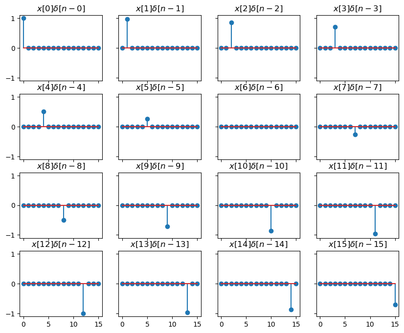

Pela figura acima, vemos que cada gráfico tem o valor do sinal $x[n]$ em um instante $k$. Então podemos reescrever o sinal $x[n]$ como uma soma de todos esses sinais mostrados acima:

$$x[n] = \displaystyle\sum_{k=-\infty}^\infty x[k]\delta[n-k]$$

Ou seja, o sinal $x[n]$ é uma soma de impulsos deslocados no tempo

Então, considerando o exposto acima e o princípio da superposição que sistemas lineares e invariantes no tempo obedecem, temos que a saída do sistema será:

$$y[n] = \displaystyle\sum_{k=-\infty}^\infty x[k]h[n-k] $$

Esta relação está representada na imagem abaixo:

[figure not shown]

Esta expressão é central no desenvolvimento da teoria de sistemas e sinais de tempo discreto e recebe o nome de **somatória de convolução**.

A somatória de convolução é uma operação entre dois sinais (no caso acima $x[n]$ e $h[n]$) e é representada pelo operador *.

$$y[n] = \displaystyle\sum_{k=-\infty}^\infty x[k]h[n-k] = x[n]*h[n]$$

Perceba que o símbolo * é apenas uma forma reduzida de representar a somatória de convolução (nunca se deve confundir com a simples multiplicação dos valores de $x$ e $h$ no instante $n$).

Além disso, não confundir com a operação de convolução utilizada nos métodos recentes de tratar imagens com redes neurais em aprendizado profundo (*deep learning*). Embora sejam conceitos relacionados, a convolução em *deep learning* é na verdade uma correlação e tem algumas diferenças.

## Formas de calcular a somatória de convolução

### Método dos impulsos unitários atrasados

Esta é a forma mais óbvia, mas na maioria das vezes não a mais prática. Este método sobrepõe as respostas ao impulso ponderadas.

Por exemplo, vamos considerar um sistema que tem a resposta ao impulso com o seguinte gráfico:

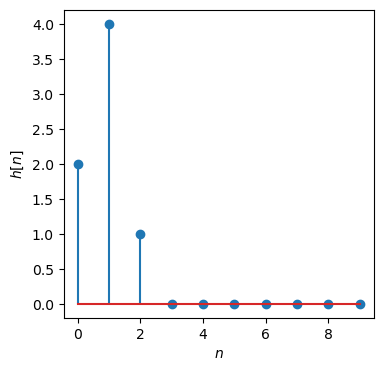

E vamos considerar como entrada um sinal com o seguinte gráfico:

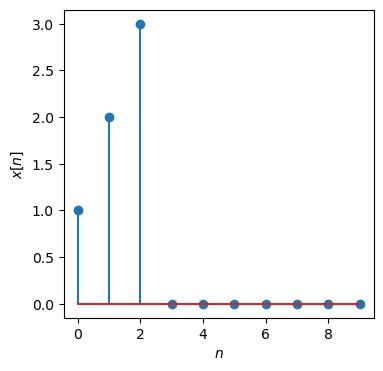

Este sinal pode ser escrito como:

$x[n] = \delta[n] + 2\delta[n-1] + 3\delta[n-2]$

Então, a resposta $y[n]$ desse sistema para essa entrada $x[n]$ é:

$y[n] = x[n]*h[n] = h[n] + 2h[n-1] + 3h[n-2]$.

Então:

$y[0] = 2$

$y[1] = 4+2\times2 = 8 $

$y[2] = 1+2\times 4+3\times 2 = 15$

$y[3] = 2\times 1+3\times 4 = 14$

$y[4] = 3\times 1 = 3$

$y[5] = 0$

Esse método é fácil de aplicar quando o sinal tem poucos valores que sejam diferentes de zero. Existe um outro método que é mais fácil de aplicar em geral (além de ser um método que também pode ser aplicado para sinais de tempo contínuo).

### Método gráfico

Esse método, por ser mais simples de se computar, é mais utilizado para calcular a convolução. Vamos voltar para a expressão da convolução:

$$y[n] = x[n]*h[n] = \displaystyle\sum_{k=-\infty}^\infty x[k]h[n-k]$$

Podemos enxergar os sinais como sendo função de $k$ ao invés de $n$. Então, para $n = 0$, temos os dois sinais a ser considerado: $x[k]$ e $h[-k]$ (a resposta ao impulso espelhada).

Vamos usar como exemplo o mesmo sinal de entrada e resposta ao impulso.

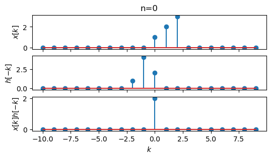

O valor de $y[0]$ é a soma de todos os valores do sinal $x[k]h[-k]$:

$y[0] = 2$

Agora, para $n=1$, o sinal $h[1-k]$ é o sinal $h[-k]$ atrasado de uma unidade de tempo.

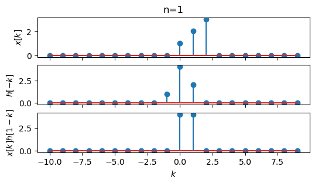

Então:

$y[1] = 4 + 4 = 8$

Então, basicamente a ideia é deslocar a resposta ao impulso espelhada, multiplicar o sinal de entrada e somar os valores para achar o valor de $y$ em cada instante. Abaixo está esse procedimento para $n$ de 0 a 5.

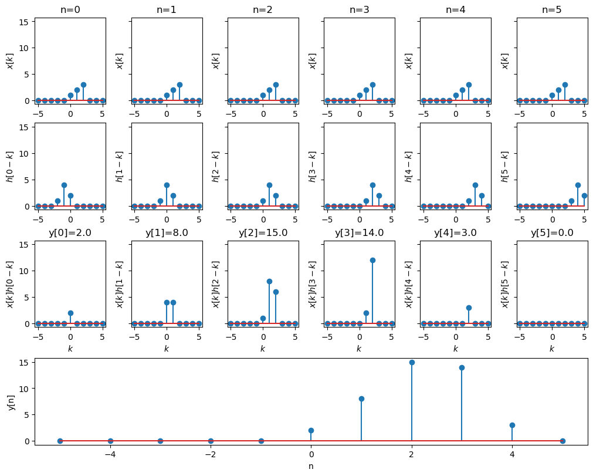

Abaixo é mostrada uma animação com a somatória de convolução entre dois sinais.

[video not shown]

O processo de cálculo da somatória de convolução parece complicado a princípio, mas com um pouco de prática se torna uma tarefa bem simples.

#### Resumo dos passos

1 - substituir $n$ por $k$ e fazer o gráfico de $x[k]$ e $h[-k]$.

2 - multiplicar os dois sinais $x[k]$ e $h[-k]$ e somar os valores de cada instante para encontrar o valor de $y[0]$.

3 - Deslocar $h[-k]$ para a direita em uma unidade tempo para gerar $h[1-k]$. Multiplique os dois sinais e some os valores em cada amostra para encontrar o valor de $y[1]$.

4 - Continue deslocando $h[-k]$ para a direita, multiplicando os $x[k]$ com a resposta ao impulo deslocada e somando os valores de cada instante para encontrar os valores de $y[n]$. Continue fazendo isso até não ter mais sobreposição entre os sinais.

## Caracterização de um SLIT pela resposta ao impulso

A principal consequência da somatória de convolução é que conseguimos caracterizar completamente um sistema linear e invariante no tempo pela sua resposta ao impulso. Perceba que não é necessário conhecer a equação de diferenças nem o diagrama de blocos do sistema se tivermos a resposta ao impulso. Portanto, **a resposta ao impulso caracteriza completamente o comportamento de um sistema linear e invariante no tempo**.

Por isso, é bastante comum no diagrama de blocos representar o sistema pela sua respsota ao impulso.

[figure not shown]

## Propriedades da convolução

### Comutativa

Uma das propriedades mais importantes, principalmente do ponto de vista prático, já que pode facilitar a computação da conolução.

> $x[n]*h[n] = h[n]*x[n]$

**Prova**:

Aqui é feita uma mudança de variável ($m = n-k$), e a prova sai facilmente.

$$ x[n]*h[n] = \displaystyle\sum_{k=-\infty}^\infty x[k]h[n-k] = \displaystyle\sum_{m=-\infty}^\infty x[n-m]h[m] = h[n]*x[n]$$

### Distributiva

> $x[n]*h_1[n]+x[n]*h_2[n] = x[n]*(h_1[n]+ h_2[n])$

A prova dessa propriedade fica para o Exercício 1.

Com esta propriedade, podemos interpretar dois sistemas ligados em paralelo, recebendo a mesma entrada, como sendo apenas um sistema que tem a resposta ao impulso igual a soma das respostas ao impulso dos dois sistemas ligados em paraleo.

[figure not shown]

Uma outra consequência dessa propriedade é que podemos dividir a resposta ao impulso de um sistema em várias partes se isso facilitar o cálculo da somatória de convolução.

### Associativa

> $x[n]*(h_1[n]*h_2[n]) = (x[n]*h_1[n])*h_2[n]$

A prova dessa propriedade fica para o Exercício 2.

A principal consequência dessa propriedade é que se tivermos dois sistemas em série, podemos considerá-los como um sistema com a resposta ao impulso sendo a convolução das respostas ao impulso dos dois sistemas.

[figure not shown]

## Exercícios

**1)** Prove a propriedade distributiva da somatória de convolução.

**2)** Prove a propriedade associativa da somatória de convolução

**3)** Considere os dois sinais a seguir:

$x[n] = 2\delta[n] - \delta[n-1] + 3\delta[n-2]$

e

$h[n] = 3\delta[n+1]+3\delta[n-1]$

Calcule e faça o gráfico do resultado de:

a) $y_1[n] = x[n]*h[n]$

b) $y_2[n] = x[n+1]*h[n]$

c) $y_3[n] = x[n]*h[n+1]$

**4)** Considere um sistema que tem a seguinte resposta ao impulso:

$h[n] = u[n+1]$

Encontre a saída deste sistema s a entrada for:

$x[n] = 0.5^{n-2}u[n-2]$

**5)** Considere um sistema linear e invariante no tempo de tempo discreto que tem a seguinte resposta ao impulso:

$h[n] = \left(\frac{1}{3}\right)^nu[n]$

a) Encontre uma constante real $C$, tal que $h[n]-Ah[n]=\delta[n]$

b) Usando o resultado anterior, determine a resposta ao impulso $g[n]$ do sistema que é o inverso de S1.

**6)** Indique se os sistemas que geraram as seguintes respostas ao impulso são ou não são estáveis:

a) $h_1[n] = 3^nu[n]$

b) $h_2[n] = u[n]- u[n-10]$

c) $h_3[n] = 5^nu[-n-2]$

d) $h_4[n] = \mathrm{sen}\left(\frac{\pi n}{3}\right)u[n]$

e) $h_5[n] = 0.5^{|n|}\cos\left(\frac{\pi n}{4}+\frac{\pi}{4} \right)$

f) $h_6[n] = 3u[n+2] - u[n] - u[n-2]$

g) $h_7[n] = ncos\left(\frac{\pi n}{4} \right)u[n]$

h) $h_8[n] = 3^nu[-n+10]$

**7)** Calcule a convolução entre os seguintes sinais:

a) $x[n]=\alpha^nu[n]$ e $y[n]=\beta^nu[n]$, com $\alpha\neq\beta$

b) $x[n] = h[n] = \alpha^nu[n]$

c) $x[n] = (-0.2)^nu[n-3]$ e $h[n] = 2^nu[1-n]$

d)

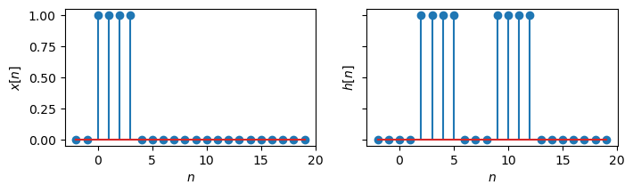

**8)** Um sistema é composto de três subsistemas ligados em série.

[figure not shown]

Os útimos dois subsistemas têm a mesma equação de diferenças e, consequentemente, a mesma resposta ao impulso, que é:

$$h_2[n] = u[n] - u[n-2] $$

A resposta ao impulso do sistema todo tem o seguinte gráfico:

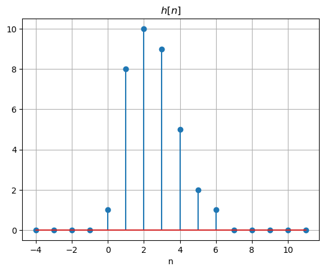

Qual a resposta ao impulso $h_1[n]$ do primeiro subsistema?

**9)** Se tivermos dois sistemas lineares e invariantes no tempo ligados em série a saída do sistema para uma mesma entrada será a mesma, não importa a ordem em que esses subsistemas são ligados (propriedade comutativa).

[figure not shown]

Considere que o sistema S1 seja linear e invariante no tempo e tenha uma resposta ao impulso igual a:

$$h_1[n] = \left(\frac{1}{3}\right)^nu[n] $$

.

O sistema S2, por outro lado, é linear mas variante no tempo. A equação de diferenças do sistema S2 é:

$$y_2[n] = nx_2[n]$$

a) Mostre que nesse caso de um dos subsistemas ser variante no tempo, mudar a ordem dos subsistemas muda a saída do sistema. Mostre isso calculando a resposta ao impulso do sistema considerando as duas ordens possíveis.

b) Considere agora que o sistemna S2 tem a seguinte equação de diferenças:

$$y_2[n] = x_2[n] + 3$$

Refaça o item a), considerando essa nova equação para S2.

## Referências

- Ulaby, FT e Yagle, AE, Signals & Systems: Theory and Applications, 2018, ss2.eecs.umich.edu
- Oppenheim, M. e Willsky, S., Sistemas e Sinais, 2010
- Lathi, BP, Sinais e Sistemas Lineares, 2007